# Hydrograph metrics

2025-09-12

## Overview

This tutorial covers:  
* Downloading flow data from USGS gauges  
* “Wrangling” the data into a more flexible format  
* Calculating basic hydrograph metrics  
* Flow Duration Curves  
* Annual Flood Frequency  
* Empirical return intervals  
* Estimating return intervals

- Calculating some of the IHA metrics

## Setup

You will need to download the:  
* `dataRetrieval` and `tidyverse` packages  
* You only need to do this once per machine  
* copy the following code into your console and run it (press enter)  
* Do **NOT** put this code into your script

```r
install.packages("dataRetrieval")
install.packages("tidyverse")
```

## Start a new script

Now that we have the packages installed, we can start a new script (white square with a green plus sign icon in the top left) and begin our analysis.

### Load Libraries

- Only need to install package once
- Need to “load” it every time

```r
library(dataRetrieval)
library(tidyverse)
```

### Download data

- We will use the `dataRetrieval` package to download data
- For a more complete tutorial on the `dataRetrival` package, [see this website](https://doi-usgs.github.io/dataRetrieval/index.html)
- Here, we will download data from the USGS gauge on the Colorado River near the UT-CO stateline
- Save variables to make download easier

```r
siteNo <- "USGS-09163500" #CO River near CO-UT stateline
# you will need to look up a site code for a different gauge for your assignment

pCode <- "00060" #discharge

# all daily data from 2003-2023
start.date <- "2003-10-01"
end.date <- "2023-12-31"
# For your assignment, make sure there is at least 10 yers of data, and change the dates as appropriate
```

- Now use the `read_waterdata_daily()` function to download the data, and save it as an object called `co_r`

```r
co_r <- read_waterdata_daily(
  monitoring_location_id = siteNo,
  parameter_code = pCode,
  time = c(start.date, end.date))
```

```
## Requesting:
## https://api.waterdata.usgs.gov/ogcapi/v0/collections/daily/items?f=json&lang=en-US&limit=10000&monitoring_location_id=USGS-09163500&parameter_code=00060&time=2003-10-01%2F2023-12-31
```

- We can now print out that that data to see what it looks like:

```r
# just first few rows:
co_r
```

```
## Simple feature collection with 7397 features and 11 fields
## Geometry type: POINT
## Dimension:     XY
## Bounding box:  xmin: -109.0271 ymin: 39.13276 xmax: -109.0271 ymax: 39.13276
## Geodetic CRS:  WGS 84
## # A tibble: 7,397 × 12
##    daily_id   parameter_code statistic_id unit_of_measure monitoring_location_id
##    <chr>      <chr>          <chr>        <chr>           <chr>
##  1 79a0ce14-… 00060          00003        ft^3/s          USGS-09163500
##  2 a650d541-… 00060          00003        ft^3/s          USGS-09163500
##  3 1fe3bfac-… 00060          00003        ft^3/s          USGS-09163500
##  4 489e2273-… 00060          00003        ft^3/s          USGS-09163500
##  5 f501fdc3-… 00060          00003        ft^3/s          USGS-09163500
##  6 258bbea6-… 00060          00003        ft^3/s          USGS-09163500
##  7 1a27c46f-… 00060          00003        ft^3/s          USGS-09163500
##  8 1f59b417-… 00060          00003        ft^3/s          USGS-09163500
##  9 2d9f137f-… 00060          00003        ft^3/s          USGS-09163500
## 10 e2be57da-… 00060          00003        ft^3/s          USGS-09163500
## # ℹ 7,387 more rows
## # ℹ 7 more variables: time_series_id <chr>, time <date>, value <dbl>,
## #   approval_status <chr>, last_modified <dttm>, qualifier <chr>,
## #   geometry <POINT [°]>
```

```r
# statistic_id == 00003 = daily
```

- You can also `View()` the whole thing with this code:
- Note that the following does not run in this tutorial for visualization purposes, but I will do it in class.

```r
View(co_r)
```

- This produces a data frame (table) with 7397 rows and 12 columns
- For our purposes, we only need the columns named:
  - `time` : In this case, the date in YYYY-MM-DD format
  - `value` which is the mean discharge (Q) for that day
    - We will rename it to be `q`
  - We could also keep the `unit_of_measure` column, bit it’s always CFS, so we will just have to remember that
- We also want to remove the “geometry attributes”
  - Discussion of this is beyone the scope of this tutorial

```r
# remove "geometry" attributes
attr(co_r, "class") <- "data.frame"

# overwrite co_r to just be the two columns
# and rename value column to be "q"
co_r <- co_r |>
  select(time, value)|>
  rename(q = value)
co_r
```

```
##            time     q
## 1    2003-10-01  2920
## 2    2003-10-02  2890
## 3    2003-10-03  2990
## 4    2003-10-04  3230
## 5    2003-10-05  3390
## 6    2003-10-06  3410
## 7    2003-10-07  3350
## 8    2003-10-08  3310
## 9    2003-10-09  3200
## 10   2003-10-10  3130
## 11   2003-10-11  3120
## 12   2003-10-12  3170
## 13   2003-10-13  3300
## 14   2003-10-14  3360
```

[output cut: 7383 more lines]

## Calculate Daily Flow Duration Curves

where $m$ is the rank of the flow, and $N$ is the number of observations in the data

- Sort the flows so that the highest is the first row, and the smallest flows is the last row

```r
daily_pe <- co_r |>
  # sort by the q column
  arrange(-q) |>
  # add a "rank" column
  mutate(m_rank = 1:n()) |>
  # calculate % exceedance
  mutate(PE = (m_rank / (n() +1)) *100)

# print out the new data object
daily_pe
```

```
##            time     q m_rank          PE
## 1    2011-06-09 46800      1  0.01351717
## 2    2011-06-08 46300      2  0.02703433
## 3    2011-06-10 45000      3  0.04055150
## 4    2011-06-11 42800      4  0.05406867
## 5    2011-06-07 42500      5  0.06758583
## 6    2011-06-12 40300      6  0.08110300
## 7    2011-06-13 39000      7  0.09462017
## 8    2008-06-04 38900      8  0.10813733
## 9    2011-06-06 38400      9  0.12165450
## 10   2008-05-23 38100     10  0.13517167
## 11   2008-06-03 37400     11  0.14868883
## 12   2011-06-18 37400     12  0.16220600
## 13   2011-06-14 37200     13  0.17572317
## 14   2014-06-03 37200     14  0.18924034
```

[output cut: 7383 more lines]

- plot the Flow Duration Curve
- x = percent exceedance (PE)
- y = q

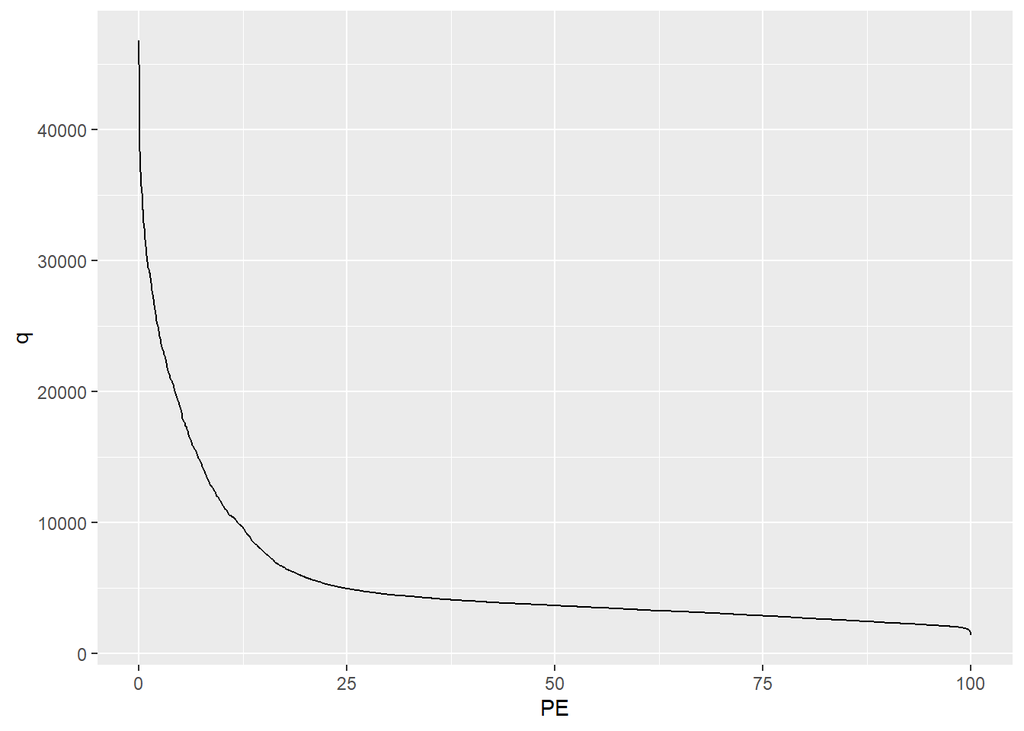

```r
ggplot(daily_pe,
       aes(x = PE,
           y = q)) +
  geom_line()
```

* FDC’s are usually plotted with a logarithmic y-axis

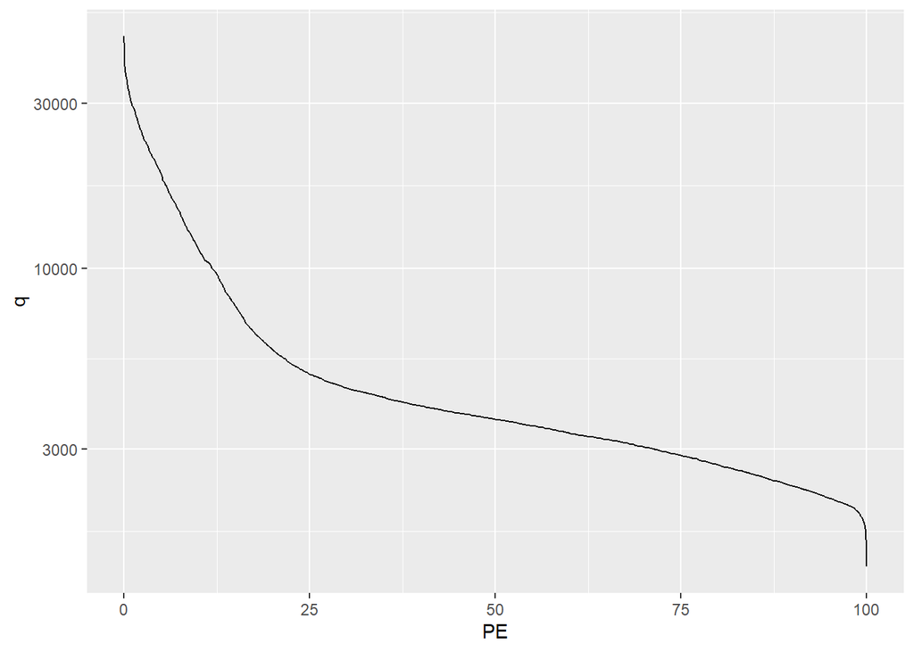

```r
ggplot(daily_pe,
       aes(x = PE,
           y = q)) +
  geom_line() +
  scale_y_log10()
```

* we can also add a title and axis labels for clarity

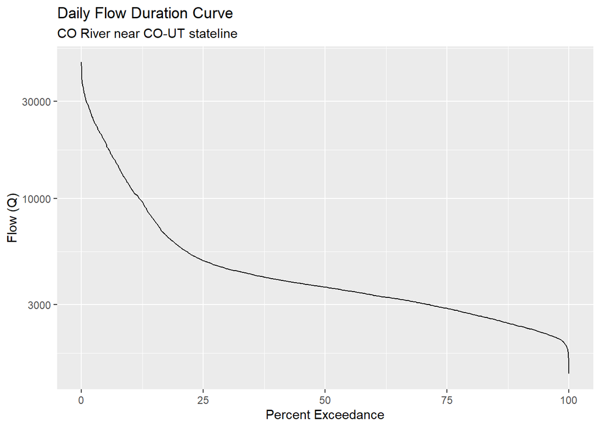

```r
ggplot(daily_pe,
       aes(x = PE,
           y = q)) +
  geom_line() +
  scale_y_log10() +
  labs(title = "Daily Flow Duration Curve",
       subtitle = "CO River near CO-UT stateline",
       y = "Flow (Q)",
       x = "Percent Exceedance")
```